# DATA SCIENCE LATAM

UN ESPACIO PARA NUNCA PARAR DE APRENDER!!

Francisco Zambrano Cruz. Abril 2020.

[figure not shown]

## Cross-Validation (Validación Cruzada)

**Cross-Validation o validación cruzada**, es un método que se emplea para estimar el test error rate de un modelo y así evaluar su capacidad predictiva. También se puede emplear para seleccionar el nivel de flexibilidad adecuado como el grado del polinomio o el número de K-Nearest-Neighbors.

En la ejecución de un modelo al utilizar 100% de sus datos podría generar un resultado que no se generaliza bien a los nuevos datos entrantes. Tambien existe otros escenario, dividir los datos originales en un conjunto de entrenamiento, que generalmente toma alrededor del 70% de los datos y un conjunto de prueba que comprende el resto, el 30%. Se libera el modelo con los datos de entrenamiento y luego usa el conjunto de pruebas para verificar cuál es la salida del modelo en comparación con las respuestas que tienes disponibles.

Sin embargo, este proceso de entrenamiento y prueba aún es algo limitado. En una capacidad, cuando está probando la salida del modelo contra los datos reservados, solo está viendo cuál es el error para esa agrupación exacta de los datos de prueba. En teoría, los **datos de la prueba deberían ser representativos** de todo el conjunto de datos, pero en la práctica hay casos en los que eso podría no ser cierto. Se debería entrenar el modelo de tal manera que pueda estar seguro de que el error es representativo de todo el conjunto de datos, no solo del segmento específico que obtiene de los datos seleccionados al azar que coloca en el conjunto de prueba.

La **validación cruzada** es una técnica estadística mediante la cual toma todo su conjunto de datos, lo divide en una serie de pequeños fragmentos de entrenamiento/prueba, evalúa el error para cada fragmento y luego promedia esos errores finales. Este enfoque termina siendo una forma más precisa de evaluar si su enfoque de modelado tiene algún problema que podría estar oculto en varias combinaciones de las partes de entrenamiento y prueba del conjunto de datos.

De hecho, ¡ya hemos realizado una forma de validación cruzada! La simple división 70/30 de entrenamiento/prueba que es un tipo de "validación cruzada". Sin embargo, existen muchas otras técnicas estadísticas de validación cruzada, y con R teniendo su base en el diseño estadístico, puede modelar muchos tipos diferentes de validación cruzada.

### Tipos de Data Set

- **Training data set**: observaciones con las que se genera el modelo.
- **Test data set**: observaciones del training data set no empleados en la creación del modelo.

### Tipos de errores

- **Training error rate:** error que comete el modelo al predecir con observaciones del training data set.
- **Test error rate:** error que comete el modelo al predecir con observaciones del test data set.

Entonces podemos decir que **Cross-Validation o validación cruzada**, se emplea para estimar el **test error rate** de un modelo y así evaluar su capacidad predictiva. También se puede emplear para seleccionar el nivel de flexibilidad adecuado como grado del polinomio o el número de K-Nearest-Neighbors.

Por lo general, en **variables cuantitativas**, el error se mide mediante **mean square error (MSE) o con el RMSE**. Cuando se trata de **variables cualitativas (clasificación)**, el error se mide como la proporción de predicciones incorrectas respecto al total de predicciones.

## Cross-Validation Simple

El método más sencillo consiste en dividir aleatoriamente las observaciones disponibles en dos grupos, uno se emplea para entrenar al modelo y otro para evaluarlo.

**LIMITACIONES:**

**VARIANZA ALTA:** La estimación del test error rate es altamente variable porque depende de qué observaciones se incluyan como set de entrenamiento y cuáles como set de validación.

**BIAS ALTO**: Esto quiere decir que al tener **pocos datos** para entrenar el modelo, se dispone de menos información, por lo que se reduce su capacidad predictiva. Lo que provocaría sobrestimación del test error.

Al tomar muestras de datos, debe tener cuidado con los cuatro niveles diferentes de sesgo y varianza que podría tener

[figure not shown]

1. **Bajo sesgo(bias), baja varianza**: El mejor de los casos. Las muestras son bastante representativas de la población.
1. **Alto sesgo(bias), baja varianza**: Todas las muestras son bastante consistentes, pero no reflejan realmente a la población.
1. **Bajo sesgo(bias), alta varianza**: Las muestras varían enormemente en su consistencia, pero algunas pueden ser representativas de la población.
1. **Alto sesgo(bias), alta varianza**:Las muestras son un poco más consistentes, pero no es probable que sean representativas de la población.

**Creación y Visualización de la Data**

```r
set.seed(2020)

x <- rnorm(100, 2, 1)

y = exp(x) + rnorm(5, 0, 2)

data <- data.frame(x, y)

head(data)
```

| x | y |
| --- | --- |
| 2.3769721 | 7.314669 |
| 2.3015484 | 8.007116 |
| 0.9019768 | 1.293459 |
| 0.8695941 | 3.152986 |
| -0.7965343 | 1.944219 |
| 2.7205735 | 11.731463 |

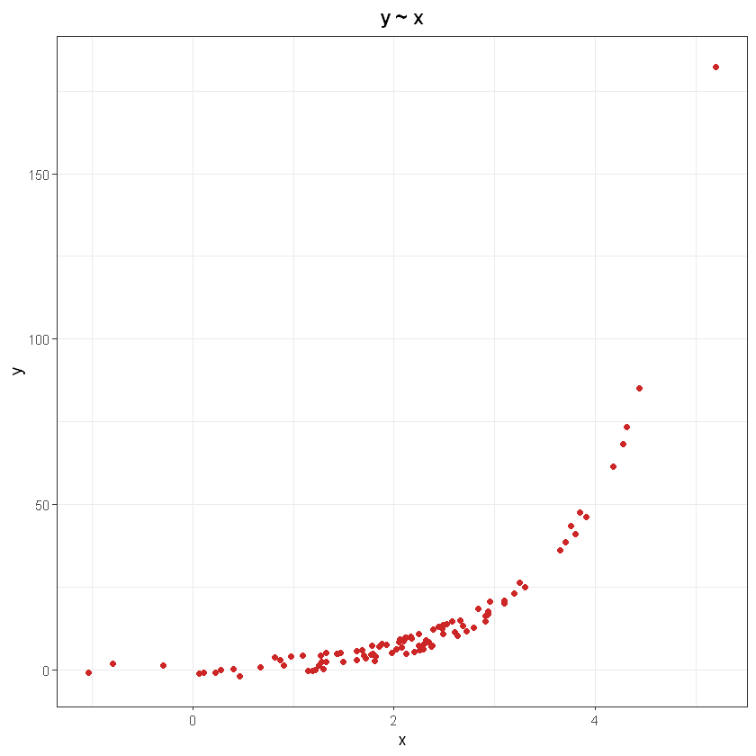

```r
library(ggplot2)
ggplot(data = data, aes(x = x, y = y)) +
 geom_point(colour = c("firebrick3")) +
 theme_bw() +
 labs(title  =  'y ~ x') +
 theme(plot.title = element_text(hjust = 0.5, face = 'bold'))
```

```r
dim(data)
```

1. 100

2. 2

**Separación de los datos en entrenamiento y prueba**

En primer lugar se separan aleatoriamente las observaciones en dos grupos training.data y test.data.

training.data tendrá en 70% de los datos y test.data el 30%

```r
## Se seleccionan los 70 índices aleatorios que formarán el training set.

data.samples <- sample(1:nrow(data), nrow(data) * 0.7, replace = FALSE)

training.data <- data[data.samples, ]

test.data <- data[-data.samples, ]
```

```r
dim(training.data)
```

1. 70

2. 2

```r
dim(test.data)
```

1. 30

2. 2

**Creación del modelo con el train data**

Se genera un modelo lineal que relacione **y** con **x** empleando únicamente los datos de training. Se recurre a la función **lm()** para generar el modelo lineal.

```r
train.linear <- lm(y ~ x, training.data)

summary(train.linear)
```

```
Call:
lm(formula = y ~ x, data = training.data)

Residuals:
   Min     1Q Median     3Q    Max
-6.252 -3.478 -1.319  1.580 33.369

Coefficients:
            Estimate Std. Error t value Pr(>|t|)
(Intercept)  -6.4039     1.5717  -4.075 0.000123 ***
x             8.2830     0.7274  11.388  < 2e-16 ***
---
Signif. codes:  0 '***' 0.001 '**' 0.01 '*' 0.05 '.' 0.1 ' ' 1

Residual standard error: 6.036 on 68 degrees of freedom
Multiple R-squared:  0.656,	Adjusted R-squared:  0.651
F-statistic: 129.7 on 1 and 68 DF,  p-value: < 2.2e-16
```

**Predicciones con el test data**

Una vez generado el modelo se emplea la función **predict()** para estimar el consumo de las 30 observaciones restantes no empleadas como entrenamiento.

```r
predicciones <- predict(train.linear, test.data)
```

```r
predicciones
```

**5**

-13.0015878679763

**6**

16.1305907366472

**9**

24.7329578798912

**15**

9.14112204402684

**16**

25.0718297727406

**17**

24.2762711836512

**28**

17.9209166156054

**30**

11.0767930766599

**32**

4.00200599101661

**34**

30.3342684584967

**35**

13.3768681155987

**37**

7.79647711931285

**39**

5.52113638436521

**40**

13.8661437143263

**43**

7.66887161002533

**46**

12.2583016774867

**47**

7.09148667512333

**48**

10.3457988303867

**56**

11.1662020881723

**62**

12.2391044339412

**64**

36.6811782547515

**68**

8.45975384517288

**72**

23.7959381962411

**82**

9.9580044655742

**83**

29.3302007752525

**85**

1.67686556527114

**86**

29.0032544202199

**89**

25.4538737904011

**94**

20.4763721609035

**99**

5.75999483892142

Dado que se conoce el valor real de los 30 valores empleados como test, se puede estimar el error de predicción del modelo. Al tratarse de una variable continua se emplea como medida de error el **MSE (mean square error)**.

**Visualizacion de los datos predichos y los valores reales**

```r
#realizamos una data frame para visualizar los valores predicho, los valores actuales y el error

df = data.frame(predicted = predicciones , actual = test.data$y,
                        SE = ((predicciones  - test.data$y)^2)
                    )
df
```

|  | predicted | actual | SE |
| --- | --- | --- | --- |
| 5 | -13.001588 | 1.944219 | 2.233771e+02 |
| 6 | 16.130591 | 11.731463 | 1.935233e+01 |
| 9 | 24.732958 | 43.678178 | 3.589214e+02 |
| 15 | 9.141122 | 8.025504 | 1.244605e+00 |
| 16 | 25.071830 | 41.245544 | 2.615890e+02 |
| 17 | 24.276271 | 38.626728 | 2.059356e+02 |
| 28 | 17.920917 | 17.682861 | 5.667051e-02 |
| 30 | 11.076793 | 9.745135 | 1.773313e+00 |
| 32 | 4.002006 | 1.529872 | 6.111447e+00 |
| 34 | 30.334268 | 85.150697 | 3.004841e+03 |
| 35 | 13.376868 | 12.386309 | 9.812074e-01 |
| 37 | 7.796477 | 3.570830 | 1.785609e+01 |
| 39 | 5.521136 | 4.986479 | 2.858583e-01 |
| 40 | 13.866144 | 13.049140 | 6.674947e-01 |
| 43 | 7.668872 | 4.297443 | 1.136653e+01 |
| 46 | 12.258302 | 6.059385 | 3.842657e+01 |
| 47 | 7.091487 | 3.117724 | 1.579079e+01 |
| 48 | 10.345799 | 6.383762 | 1.569774e+01 |
| 56 | 11.166202 | 4.883792 | 3.946867e+01 |
| 62 | 12.239104 | 7.512399 | 2.234174e+01 |
| 64 | 36.681178 | 182.335317 | 2.121513e+04 |
| 68 | 8.459754 | 4.845326 | 1.306409e+01 |
| 72 | 23.795938 | 36.338768 | 1.573226e+02 |
| 82 | 9.958004 | 5.226703 | 2.238522e+01 |
| 83 | 29.330201 | 73.579295 | 1.957982e+03 |
| 85 | 1.676866 | 4.146049 | 6.096867e+00 |
| 86 | 29.003254 | 68.399667 | 1.552077e+03 |
| 89 | 25.453874 | 47.580328 | 4.895800e+02 |
| 94 | 20.476372 | 26.434828 | 3.550320e+01 |
| 99 | 5.759995 | 5.109927 | 4.225877e-01 |

**Calculo del MSE**

```r
#MSE

mean((predicciones  - test.data$y)^2)
```

989.854916794581

La estimación de test error rate del modelo de regresión lineal creado es de 989.85

**Cross Validation simple con 100 repeticiones para el calculo del Test error rate**

Como se ha comentado previamente, una de las principales desventajas de cross-validation simple es que la estimación de error varía mucho dependiendo de cómo se hayan repartido los datos entre set de entrenamiento y set de validación. A continuación se calcula el test error rate para 100 repeticiones de la validación, repartiendo en cada una de ellas los datos de forma aleatoria.

```r
cv_MSE <- rep(NA,100)

for (i in 1:100) {

  data.samples <- sample(1:nrow(data), nrow(data) * 0.7, replace = FALSE)

  training.data <- data[data.samples, ]

  test.data <- data[-data.samples, ]

  train.linear <- lm(y ~ x, training.data)

  predicciones <- predict(train.linear, test.data)

  cv_MSE[i] <- mean((predicciones  - test.data$y)^2)
}
```

```r
cv_MSE
```

1. 210.17744395591

2. 971.841710394797

3. 175.403487958407

4. 125.676404602192

5. 649.252227627457

6. 642.992966141915

7. 154.849214231416

8. 118.352439667622

9. 648.683475472347

10. 109.802094710369

11. 75.3153613107118

12. 131.058191634284

13. 133.51309315411

14. 609.049728948581

15. 147.634359931176

16. 71.9121605940358

17. 115.455965596292

18. 139.943941512708

19. 82.8818543833078

20. 664.043989887876

21. 752.55176496377

22. 76.721408152681

23. 90.5000022537766

24. 696.822145909485

25. 188.896978624455

26. 89.3512513781447

27. 140.168212221428

28. 600.884023614567

29. 105.356605851319

30. 202.716782859309

31. 605.356203661723

32. 92.9623387242676

33. 98.4501901887855

34. 66.0456934194833

35. 129.697517992816

36. 132.37024202031

37. 74.8594417836744

38. 127.959192477511

39. 81.6722840361022

40. 760.979635498988

41. 76.4229817578194

42. 643.498762933671

43. 78.7659130176635

44. 174.876875409342

45. 80.5561115954527

46. 695.940888656713

47. 125.305085968126

48. 105.007549897349

49. 133.589585994777

50. 144.139203754794

51. 126.789946916769

52. 168.170235785217

53. 150.286225422725

54. 682.957442048187

55. 141.814871222535

56. 130.629098040417

57. 101.586801229779

58. 258.876773505567

59. 101.555221004508

60. 99.6114805331057

61. 181.605043431914

62. 90.9910244427385

63. 618.080799404444

64. 116.76810487963

65. 189.275860330198

66. 209.770481190838

67. 115.412698446845

68. 693.528295648526

69. 611.781265590264

70. 655.346114701069

71. 150.605658314245

72. 713.669460388389

73. 49.285948576252

74. 266.146559942935

75. 631.472069020086

76. 94.987301279852

77. 637.933852483111

78. 609.283077007092

79. 90.8752824995414

80. 92.3447520829638

81. 86.5311673086537

82. 625.801181339649

83. 87.2466403275177

84. 83.5673497864494

85. 704.217183619327

86. 59.97752983309

87. 153.802875022846

88. 661.479445302945

89. 699.926953685276

90. 77.0096392981729

91. 169.586033107473

92. 133.283291472125

93. 102.271457766592

94. 599.888937310658

95. 138.815688673241

96. 95.7928004670081

97. 700.787509956781

98. 125.429368625879

99. 112.857219819696

100. 152.263235491599

```r
mean(cv_MSE)
```

277.022422399185

Podemos ver las salidas de los valores MSE, slgunos errores son tan bajos y otros tan altos. Hay un alto grado de variabilidad en el MSE de estos datos, se ha mitigado esto tomando el promedio de esos valores para obtener un número final que sea más representativo del error.

La representación gráfica de las observaciones y del modelo, muestra que la relación entre las variables no es del todo lineal.

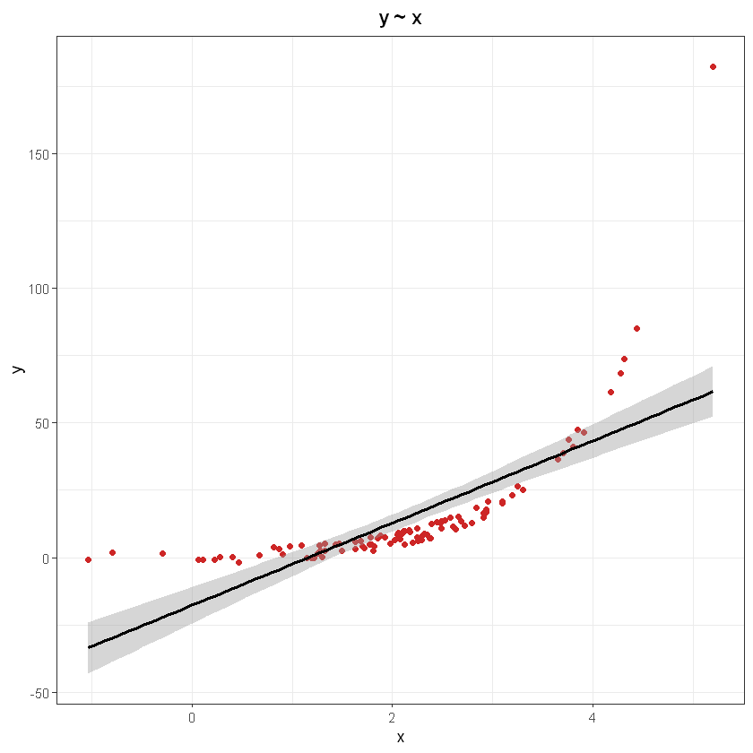

```r
ggplot(data = data, aes(x = x, y = y)) +
geom_point(colour = c("firebrick3")) +
geom_smooth(method = "lm", colour = "black") +
theme_bw() +
labs(title  =  'y ~ x') +
theme(plot.title = element_text(hjust = 0.5, face = 'bold'))
```

Al parecer, un modelo lineal no se ajusta bien los datos. Se puede mejorar el modelo subiendo el grado del polinomio, pero hay que saber hasta q punto hay subirlo. Para conocer cual es el grado de polinomio adecuado, podemos probar diferentes grados y asi ver en cual se obtiene un menor **MSE**.

**Flexibilidad del modelo mediante Cross_Validation Simpl: elección del grado polinomio del modelo**

Introduciendo flexibilidad en el modelo mediante polinomios de mayor grado podría reducir el error de predicción. La validación cruzada nos permite identificar con qué grado de polinomio se consigue el mejor modelo (menor test cv-MSE).

A continuación se ajustan 10 modelos distintos empleando polinomios de grado 1 hasta 10 y se registra el cv-MSE para cada uno. La función **poly()** permite determinar el grado de polinomio empleado.

```r
cv_MSE <- rep(NA,10)

set.seed(2020)
data.samples <- sample(1:nrow(data), nrow(data) * 0.7, replace = FALSE)
training.data <- data[data.samples, ]
test.data <- data[-data.samples, ]

for (i in 1:10) {

  train.linear <- lm(y ~ poly(x,i), training.data)

  predicciones <- predict(train.linear, test.data)

  cv_MSE[i] <- mean((predicciones  - test.data$y)^2)
}
```

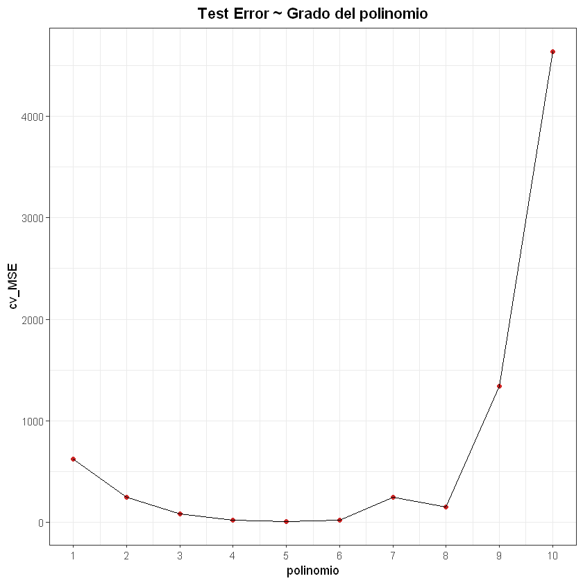

```r
ggplot(data = data.frame(polinomio = 1:10, cv_MSE = cv_MSE),
       aes(x = polinomio, y = cv_MSE)) +
geom_point(colour = c("firebrick3")) +
geom_path() +
scale_x_continuous(breaks = c(0:10)) +
theme_bw() +
labs(title  =  'Test Error ~ Grado del polinomio') +
theme(plot.title = element_text(hjust = 0.5, face = 'bold'))
```

**Modelo final**

```r
modelo_final <- lm(y ~ poly(x,2), data)

summary(modelo_final)
```

```
Call:
lm(formula = y ~ poly(x, 2), data = data)

Residuals:
    Min      1Q  Median      3Q     Max
-23.908  -4.119   0.604   3.746  61.420

Coefficients:
            Estimate Std. Error t value Pr(>|t|)
(Intercept)  14.4440     0.8555   16.88   <2e-16 ***
poly(x, 2)1 169.9885     8.5548   19.87   <2e-16 ***
poly(x, 2)2 133.7448     8.5548   15.63   <2e-16 ***
---
Signif. codes:  0 '***' 0.001 '**' 0.01 '*' 0.05 '.' 0.1 ' ' 1

Residual standard error: 8.555 on 97 degrees of freedom
Multiple R-squared:  0.8683,	Adjusted R-squared:  0.8655
F-statistic: 319.6 on 2 and 97 DF,  p-value: < 2.2e-16
```

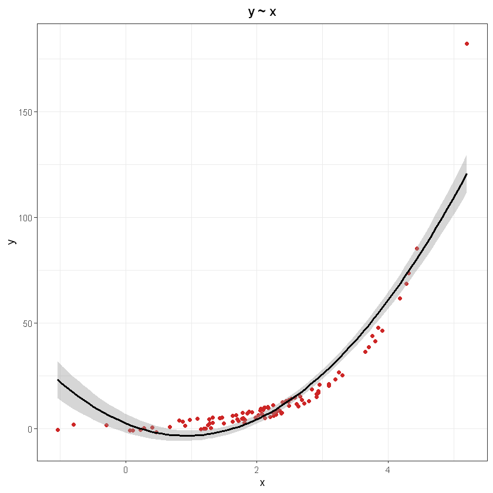

```r
library(ggplot2)
ggplot(data = data, aes(x = x, y = y)) +
 geom_point(colour = c("firebrick3")) +
 stat_smooth(method = "lm", formula = y ~ poly(x, 2), color = "black") +
 theme_bw() +
 labs(title  =  'y ~ x') +
 theme(plot.title = element_text(hjust = 0.5, face = 'bold'))
```

## K-Fold Cross-Validation

El método **K-Fold Cross-Validation** es también un proceso iterativo. Consiste en dividir los datos de forma aleatoria en k grupos de aproximadamente el mismo tamaño. k-1 grupos se emplean para entrenar el modelo y uno de los grupos se emplea como test, este proceso se repite k veces utilizando un grupo distinto como test en cada iteración. El proceso genera k estimaciones del test error cuyo promedio se emplea como estimación final.

[figure not shown]

**Observaciones:**

El número de iteraciones necesarias viene determinado por el valor k escogido. Por lo general se recomienda un k entre 5 y 10.

La principal ventaja de K-fold CV es que consigue una estimación precisa del test error rate gracias a un mejor Balance entre bias y varianza. En el método K-fold CV los k grupos empleados como entrenamiento son mucho menos solapantes, lo que se traduce en menor varianza al promediar las estimaciones de error.

En R se puede realizar CV de cualquier **generalized linear model** creado mediante **glm()** empleando la función `cv.glm()` del paquete **boot**. La función **glm()** engloba diferentes tipos de modelos lineales que se especifican mediante el argumento **family**. En el caso de regresión lineal no se especifica ningún tipo de familia y es equivalente a emplear la función lm(). Para regresión logística se emplea **family=binomial**.

La función **cv.glm()** calcula el error de predicción mediante **cross-validation**. Si el argumento **k no se especifica**, se le asigna automáticamente el número de observaciones empleadas para crear el modelo, por lo que se realiza un **leave-one-out cross-validation** (es decir una 1 observacion para test y el resto para entramiento). La función devuelve una lista con múltiples componentes, el resultado de la validación se almacena dentro del vector **delta** que contiene la estimación de error con y sin corrección.

```r
library(boot)
```

```r
set.seed(2020)

x <- rnorm(100, 2, 1)

y = exp(x) + rnorm(5, 0, 2)

data <- data.frame(x, y)

head(data)
```

| x | y |
| --- | --- |
| 2.3769721 | 7.314669 |
| 2.3015484 | 8.007116 |
| 0.9019768 | 1.293459 |
| 0.8695941 | 3.152986 |
| -0.7965343 | 1.944219 |
| 2.7205735 | 11.731463 |

```r
# Se genera el modelo lineal
modelo <- glm(y ~ x, data = data)

# Se emplea la función cv.glm() para la validación, empleando en este caso k=10
set.seed(1)

errors <- cv.glm(data = data, glmfit = modelo, K = 10)

errors$delta
```

1. 292.514472143978

2. 290.193415117553

Si se estudia la influencia de la **flexibilidad del modelo**, los resultados muestran la misma tendencia que Cross-Validation Simple. Se obtiene una mejora importante empleando una función cuadrática o cubica en comparación al modelo lineal. Para polinomios de grado > 3 la mejora es mínima.

```r
cv_MSE_k10 <- rep(NA,10)

for (i in 1:10) {
  modelo <- glm(y ~ poly(x, i), data = data)
  set.seed(2)
  cv_MSE_k10[i] <- cv.glm(data = data, glmfit = modelo, K = 10)$delta[1]
}
```

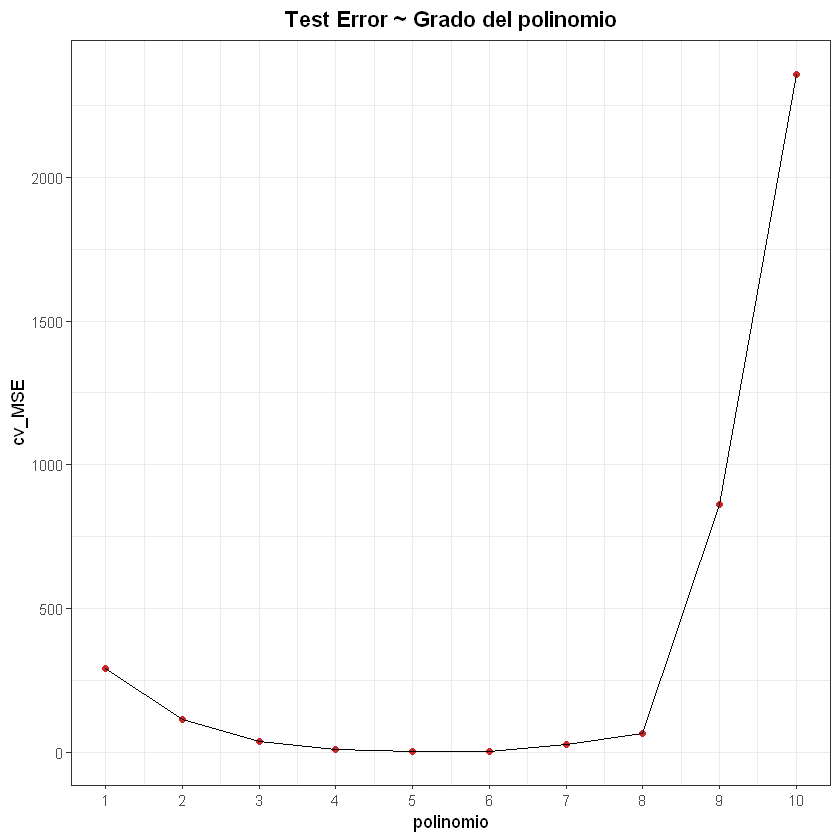

```r
ggplot(data = data.frame(polinomio = 1:10, cv_MSE = cv_MSE_k10),
       aes(x = polinomio, y = cv_MSE)) +
geom_point(colour = c("firebrick3")) +
geom_path() +
scale_x_continuous(breaks = c(0:10)) +
theme_bw() +
labs(title  =  'Test Error ~ Grado del polinomio') +
theme(plot.title = element_text(hjust = 0.5, face = 'bold'))
```

```r
# Se genera el modelo cuadratico
modelo <- glm(y ~ poly(x, 2), data = data)

# Se emplea la función cv.glm() para la validación, empleando en este caso k=10
set.seed(1)

errors <- cv.glm(data = data, glmfit = modelo, K = 10)

errors$delta
```

1. 129.108072271804

2. 125.540725240269

En este ejemplo particular hemos visto que el test.error en un modelo cuadrático es menor en comparación a un modelo lineal.